# いろいろなデータを 地図にかさねる

Kanazawa.R #6

伊東宏樹

2026-11-28

## 今回の内容

- いろいろなデータを地図に重ねる
- 例題: **人口の多いのにバス停がない地域はどこか?**
- やること
  - 国土数値情報の利用
  - 標準地域メッシュの利用
  - sfパッケージ
  - ggplotでの作図
  - Leafletの地図にのせる

## 国土数値情報

- https://nlftp.mlit.go.jp/ksj/
- 国土交通省が提供している
- 国土、政策区域、地域、交通、各種統計の5分類
- 形式: シェープファイル, XML, GeoJSON
  - Rからは（Rでなくとも）GeoJSONがおすすめ

## 2026年の石川県の行政区域データ

- 国土数値情報: [行政区域データ](https://nlftp.mlit.go.jp/ksj/gml/datalist/KsjTmplt-N03-2026.html)から、2026年の石川県の行政区域データをダウンロードしておく
- GeoJSONファイルを読み込む
  - sfパッケージの`st_read()`または`read_sf()`関数
- 座標参照系（CRS）はJGD2011（EPSG:6668）

```r
data_file <- file.path("data", "N03-20260101_17_GML",
                       "N03-20260101_17.geojson")
isikawa <- sf::st_read(data_file, quiet = TRUE)
sf::st_crs(isikawa) # CRSの確認
```

```
Coordinate Reference System:
  User input: JGD2011
  wkt:
GEOGCRS["JGD2011",
    DATUM["Japanese Geodetic Datum 2011",
        ELLIPSOID["GRS 1980",6378137,298.257222101,
            LENGTHUNIT["metre",1]]],
    PRIMEM["Greenwich",0,
        ANGLEUNIT["degree",0.0174532925199433]],
    CS[ellipsoidal,2],
        AXIS["geodetic latitude (Lat)",north,
            ORDER[1],
            ANGLEUNIT["degree",0.0174532925199433]],
        AXIS["geodetic longitude (Lon)",east,
            ORDER[2],
            ANGLEUNIT["degree",0.0174532925199433]],
    ID["EPSG",6668]]
```

## 座標参照系（CRS）

地球上の位置をどのように数値座標に落とすか

- 地理座標系（←今回はこちらだけ）
  - 緯度と経度（単位は度）
  - GPSの位置（“WGS84”）など
- 投影座標系（←距離や面積を測定したいとき）
  - 平面に投影した座標（単位はm）
  - 日本の平面直角座標系など

地図にデータを重ねるときは、**座標参照系をあわせる**

## 石川県の行政区域をggplotで描画

ggplotで`geom_sf()`を関数を使用

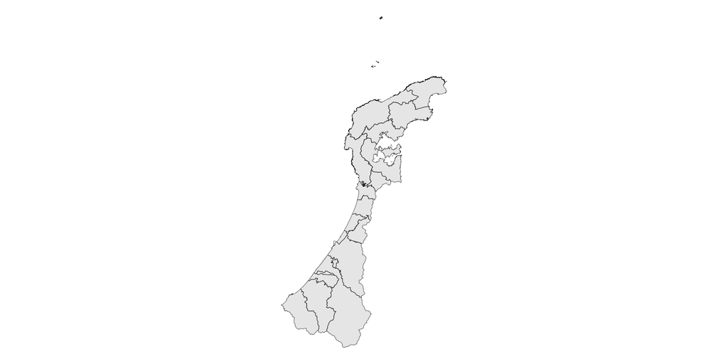

```r
ggplot(isikawa) +
  geom_sf() +
  theme_void()
```

## 標準地域メッシュ

日本の地域をメッシュに区切って扱いやすくしたもの、メッシュ単位の統計データも各種あり（将来人口推計も）

|  | 緯度差、経度差 | 1辺の長さ |
| --- | --- | --- |
| 1次メッシュ | 緯度差40分、経度差1度 | 約80km |
| 2次メッシュ | 緯度差5分、経度差7分30秒 | 約10km |
| 3次メッシュ | 緯度差30秒、経度差45秒 | 約1km |

※ 3次メッシュをさらに細分化したものもあり

## 石川県の3次メッシュの作成

石川県の領域の3次（1km）メッシュ（`isikawa_mesh`）をつくっておく

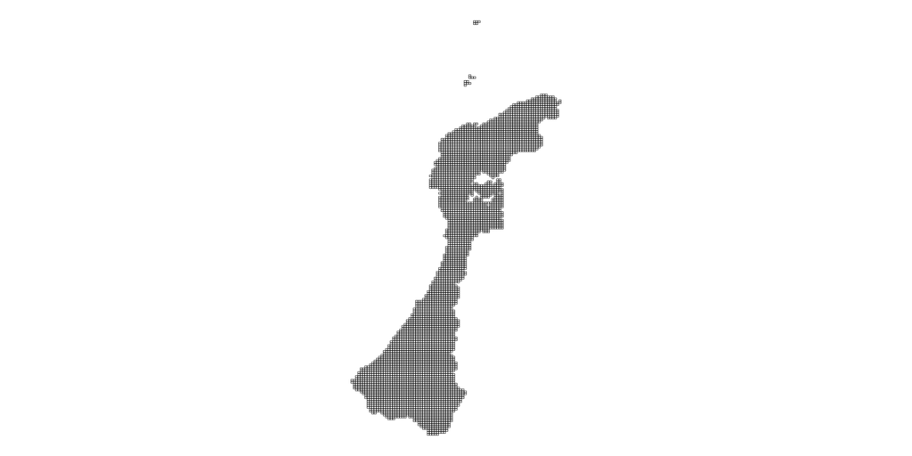

```r
ggplot(isikawa_mesh) +
  geom_sf() +
  theme_void()
```

## 人口のデータ

- 国土数値情報: [1kmメッシュ別将来推計人口データ（R6国政局推計）](https://nlftp.mlit.go.jp/ksj/gml/datalist/KsjTmplt-mesh1000r6.html)
  - 2020年時点での、3次メッシュごとの将来の推計人口

石川県のデータをダウンロードしておく

```r
pref_data_file <- file.path("data", "1km_mesh_2024_17_GEOJSON",
                       "1km_mesh_2024_17.geojson")
# CRSはEPSG:6668 (JGD2011)
d_ppl <- st_read(pref_data_file, quiet = TRUE) |>
  # MESH_IDをmeshcode型に
  dplyr::mutate(MESH_ID = jpmesh::meshcode(MESH_ID))
```

## 使用する列（変数）

- `PTN_2020`: 2020年の総人口
- `PT00_2050`: 2050年での推計総人口（秘匿含む）

※ 2020年の総人口=0のメッシュはデータに含まれていない（欠損値になっている）と思われる

## 2020年の石川県の人口分布

```r
# 1kmメッシュの人口の最大値を10000単位で切り上げて、凡例の上限にする
max_popl <- ceiling(max(c(d_ppl$PTN_2020, d_ppl$PT00_2050),
                        na.rm = TRUE) / 10000) * 10000
ggplot(d_ppl) +
  geom_sf(aes(fill = PTN_2020), color = NA) +
  scale_fill_viridis_c(name = "人口",
                       transform = "log1p",
                       limits = c(1, max_popl),
                       breaks = c(1, 10, 100, 1000, 10000)) +
  labs(title = "2020年の1kmメッシュごと人口") +
  theme_void(base_family = jp_font)
```

## 2020年の石川県の人口分布

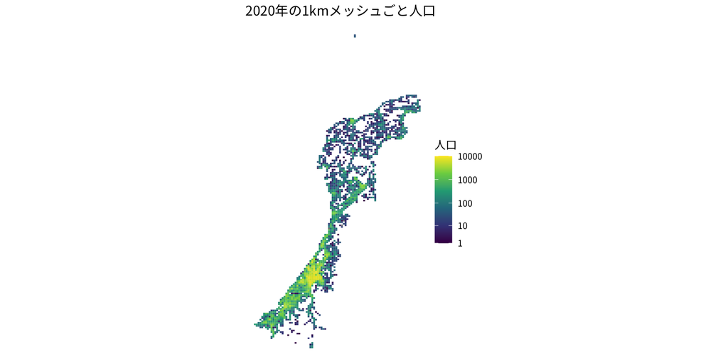

## 全メッシュでプロット

人口がNA（記載なし=人口0）のところは白色に(`na.value = "white"`)

```r
d_ppl_mesh <- isikawa_mesh |> # メッシュを結合する
  dplyr::left_join(st_drop_geometry(d_ppl), by = "MESH_ID")
ggplot(d_ppl_mesh) +
  geom_sf(aes(fill = PTN_2020), color = "gray") +
  scale_fill_viridis_c(name = "人口",
                       transform = "log1p",
                       limits = c(1, max_popl),
                       breaks = c(1, 10, 100, 1000, 10000),
                       na.value = "white") +
  labs(title = "1kmメッシュごとの2020年の総人口") +
  theme_void(base_family = jp_font)
```

## 全メッシュでプロット

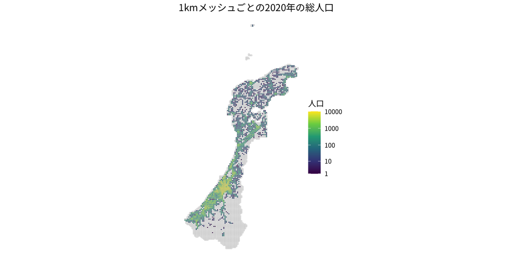

## 2050年の石川県の推計人口分布

2050年の推計値が0のところも白色にする

※ 推計時点では2024年の能登半島地震の影響は考慮されていない

```r
d_ppl_mesh |>
  # 推計人口が0のところをNAに
  dplyr::mutate(PT00_2050 = dplyr::na_if(PT00_2050, 0)) |>
  ggplot() +
  geom_sf(aes(fill = PT00_2050), color = "gray") +
  scale_fill_viridis_c(name = "人口",
                       transform = "log1p",
                       limits = c(1, max_popl),
                       breaks = c(1, 10, 100, 1000, 10000),
                       na.value = "white") +
  labs(title = "1kmメッシュごとの2050年の推計総人口") +
  theme_void(base_family = jp_font)
```

## 2050年の石川県の推計人口分布

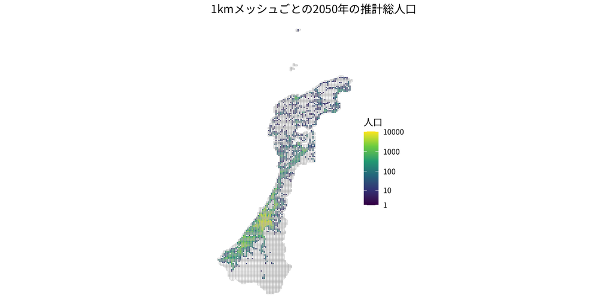

## バス停位置のデータ

- 国土数値情報: [バス停留所データ](https://nlftp.mlit.go.jp/ksj/gml/datalist/KsjTmplt-P11-2022.html)（2022年度版）

石川県のデータをダウンロードしておく

```r
busstop_data_file <- file.path("data", "P11-22_17_SHP",
                               "P11-22_17.geojson")
d_bus <- st_read(busstop_data_file, quiet = TRUE)
# CRSは6668 JGD(2011)
```

## 3次メッシュごとに含まれるバス停数を計算

```r
d_bus_mesh <- d_bus |>
  dplyr::mutate(
    MESH_ID = jpmesh::coords_to_mesh(geometry = geometry,
                                     to_mesh_size = 1)
  ) |>
  st_drop_geometry() |>     # geometryを削除
  dplyr::count(MESH_ID) |>  # MESH_IDごとに列数を数える
  dplyr::select(MESH_ID, n) # MESH_IDとバス停数nの列だけにする
```

## Leaflet地図と重ねる（準備）

- 人口データとバス停データを結合
- あとで使うPTN_2020（2020年の総人口）とn（バス停数）は、NAを0に置換
- 地理院タイルのURLを用意しておく
- カラーパレットを作成（バス停数の値に応じて色を変える）

```r
d_ppl_bus <- d_ppl_mesh |>
  dplyr::left_join(d_bus_mesh, by = "MESH_ID") |>
  tidyr::replace_na(list(PTN_2020 = 0, n = 0))
gsi_url <- "https://cyberjapandata.gsi.go.jp/xyz/std/{z}/{x}/{y}.png"
gsi_attr <- "<a href='https://maps.gsi.go.jp/development/ichiran.html'>国土地理院</a>"
pal_bus <- colorNumeric("YlOrRd", domain = d_ppl_bus$n,
                        na.color = "white")
```

## Leaflet地図と重ねる

`d_ppl_bus`のCRSを `st_transform()`でWGS84（EPSG:4326）に変換して、地理院タイルに重ねる

```r
leaflet(data = st_transform(d_ppl_bus, 4326)) |> # WGS84
  addTiles(urlTemplate = gsi_url,
           attribution = gsi_attr) |>
  setView(lng = 136.65, lat = 36.75, zoom = 8) |>
  # バス停がNAまたは0のメッシュは塗りつぶしを透明にする
  addPolygons(color = ~pal_bus(n), fillColor = ~pal_bus(n),
              opacity = 0.2,
              fillOpacity = ~if_else(is.na(n) | n == 0, 0, 0.7)) |>
  addLegend(pal = pal_bus, values = d_ppl_bus$n,
            title = "バス停数",
            position = "bottomright")
```

## Leaflet地図と重ねる

[interactive chart not shown]

## 人口とバス停数との関係

```r
ggplot(d_ppl_bus, aes(x = PTN_2020, y = n)) +
  geom_point(alpha = 0.6) +
  scale_x_continuous(transform = "log1p",
                     breaks = c(0, 1, 5, 10, 50, 100, 500,
                                1000, 5000, 10000),
                     minor_breaks = NULL) +
  labs(title = "1kmメッシュごとの人口とバス停数との関係",
       x = "人口", y = "バス停数") +
  theme_bw(base_family = jp_font)
```

## 人口とバス停数との関係

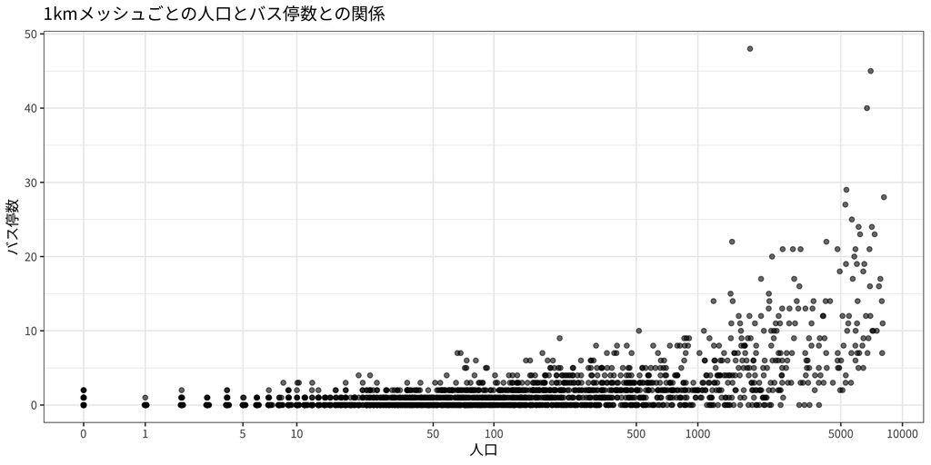

## 人口が多いのにバス停がない地域

メッシュの人口が1000人以上いるけれども、バス停がないところを抽出

```r
limit_min <- 1000
d_no_bus <- d_ppl_bus |>
  dplyr::filter(PTN_2020 >= limit_min, n == 0)
```

## 結果から市町村コードを表示

```r
d_no_bus |>
  dplyr::pull(SHICODE) |>
  table()
```

```
17201 17203 17206 17209 17210 17211 17361
    5     3     1    10     1     1     6
```

市町村コードは、17201: 金沢市、17203: 小松市、17206: 加賀市、17209: かほく市、17210: 白山市、17211: 能美市、17361: 津幡町です。

## 地図に表示

当該3次メッシュを赤色で表示

```r
d_ppl_mesh |>
  ggplot() +
  geom_sf(aes(fill = PTN_2020), color = "gray", alpha = 0.5) +
  scale_fill_viridis_c(name = "人口",
                       transform = "log1p",
                       limits = c(1, max_popl),
                       breaks = c(1, 10, 100, 1000, 10000),
                       na.value = "white") +
  geom_sf(data = d_no_bus, color = "red") +
  labs(title = "人口が多いがバス停がないメッシュ") +
  theme_void(base_family = jp_font)
```

## 地図に表示

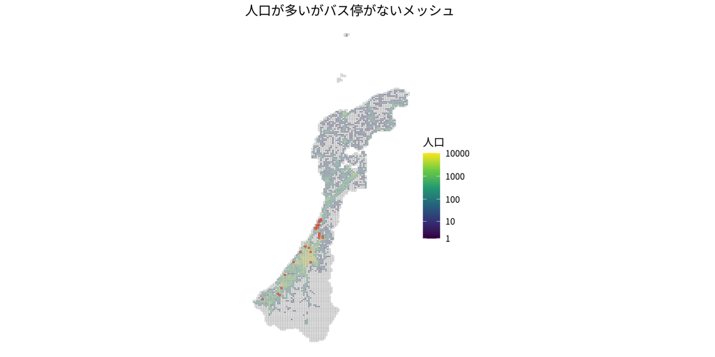

## 行政区域とかさねる

かほく市以南の市町を抽出

```r
limit_max <- ceiling(max(d_no_bus$PTN_2020,
                         na.rm = TRUE) / 1000) * 1000
isikawa |>
  dplyr::filter(N03_004 %in% c("内灘町", "かほく市", "津幡町", "金沢市",
                               "白山市", "能美市", "小松市", "加賀市")) |>
  ggplot() +
  geom_sf() +
  geom_sf(data = d_no_bus, aes(fill = PTN_2020)) +
  scale_fill_viridis_c(name = "人口",
                       transform = "log1p",
                       limits = c(limit_min, limit_max),
                       breaks = seq(limit_min, limit_max,
                                    by = 1000),
                       na.value = "white") +
  labs(title = "人口が多いがバス停がないメッシュ",
       fill = "人口") +
  theme_void(base_family = jp_font)
```

## 行政区域とかさねる

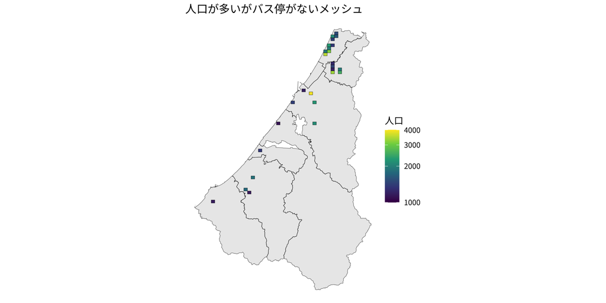

## 拡大できるようLeafletと重ねる

```r
pal_pop <- colorNumeric("YlOrRd", domain = d_no_bus$PTN_2020,
                        na.color = "white")
# CRSをWGS84に変換
map_no_bus <- leaflet(data = st_transform(d_no_bus, crs = 4326)) |>
  addTiles(urlTemplate = gsi_url,
           attribution = gsi_attr) |>
  setView(lng = 136.7, lat = 36.75, zoom = 12) |>
  addPolygons(color = ~pal_pop(PTN_2020), fillColor = ~pal_pop(PTN_2020),
              opacity = 0.2, fillOpacity = 0.7) |>
  addLegend(pal = pal_pop, values = d_no_bus$PTN_2020,
            title = "人口",
            position = "bottomright")
```

## 人口の割にバス停がない地域

[interactive chart not shown]

## バス停を追加表示

`d_bus`の座標参照系（CRS）をWGS84（EPSG: 4326）に変換する

```r
map_no_bus |>
  addCircleMarkers(data = st_transform(d_bus, crs = 4326),
                                              # WGS84
                   radius = 4, weight = 3)
```

## バス停を追加表示

[interactive chart not shown]

## 逆に人口は0でバス停はあるところ

```r
d_bus0_pop <- d_ppl_bus |>
  dplyr::filter(PTN_2020 == 0, n > 0)
```

## 地図表示

`d_bus0_pop`の座標参照系（CRS）をWGS84（EPSG: 4326）に変換する

```r
leaflet(data = st_transform(d_bus0_pop, crs = 4326)) |>
                                        # WGS84
  addTiles(urlTemplate = gsi_url,
           attribution = gsi_attr) |>
  addCircleMarkers(data = st_transform(d_bus, crs = 4326),
                   radius = 3, weight = 2, opacity = 0.2) |>
  addPolygons(color = "red")
```

## 地図表示

[interactive chart not shown]

## おわりに

### ポイント

- オープンデータの利用
- 地理データ: Rのsfパッケージ
- 座標系（CRS）
- 標準地域メッシュの利用